# Coursera Practical Machine Learning Project

Srinivas Nakka

January 15, 2017

## Introduction

Using devices such as Jawbone Up, Nike FuelBand, and Fitbit it is now possible to collect a large amount of data about personal activity relatively inexpensively. These type of devices are part of the quantified self movement - a group of enthusiasts who take measurements about themselves regularly to improve their health, to find patterns in their behavior, or because they are tech geeks. One thing that people regularly do is quantify how much of a particular activity they do, but they rarely quantify how well they do it. In this project, the goal will be to use data from accelerometers on the belt, forearm, arm, and dumbell of 6 participants. They were asked to perform barbell lifts correctly and incorrectly in 5 different ways. More information is available from the website here: http://groupware.les.inf.puc-rio.br/har (see the section on the Weight Lifting Exercise Dataset).

## Getting and Cleaning Data

The training data for this project are available here:

https://d396qusza40orc.cloudfront.net/predmachlearn/pml-training.csv

The test data are available here:

https://d396qusza40orc.cloudfront.net/predmachlearn/pml-testing.csv

The data for this project come from this source: http://groupware.les.inf.puc-rio.br/har.

### Data Processing

#### Reading the Data

```r
suppressWarnings(suppressMessages(library(caret)))
suppressWarnings(suppressMessages(library(rpart)))
suppressWarnings(suppressMessages(library(rattle)))
suppressWarnings(suppressMessages(library(randomForest)))
suppressWarnings(suppressMessages(library(gbm)))
suppressWarnings(suppressMessages(library(reshape2)))
suppressWarnings(suppressMessages(library(plyr)))


training <- read.csv("~/pml-training.csv", na.strings = c("NA","","#DIV/0!"))
testing <- read.csv("~/pml-testing.csv", na.strings = c("NA","","#DIV/0!"))
```

#### Cleaning data

In order to find the less effective predictors we need to verify the number of values exist for each predictor and then decide. We will check how many “NA” values exist for each predictor and verify.

```r
sort(unique(colSums(is.na(training))))
```

```
##  [1]     0 19216 19217 19218 19220 19221 19225 19226 19227 19248 19293
## [12] 19294 19296 19299 19300 19301 19622
```

The “NA” values in a column are either zero or 19216 and above out of total 19622 values. That means 97.8% or more. So the contribution of these predictors is very negligible, hence these need not be considered in our training method. The predictors which have zero ’NA’values only are considered.

```r
training_clean <- training[ ,colSums(is.na(training)) == 0]
```

Assuming the first seven predictors are user name, time stamps etc. will not contribute anything in the output. Therefore these can also be removed

```r
training_clean <- training_clean[,-c(1:7)]
```

Test data also should be contained the same columns as that of training data except the last variable “classe”. After cleanup training_clean has 53 predictors. So the test data after cleanup should be

```r
test_clean <- testing[names(training_clean[,-53])]
```

For validation purpose, the cleaned training data is further divided into two parts. 70% of data is used for training and 30% of data is used for validation.

```r
set.seed(5678)
inTrain <- createDataPartition(training_clean$classe, p = 0.7,  list = FALSE)
trainData <- training_clean[inTrain,]
validData <- training_clean[-inTrain,]
```

## Model Selection

For cross validation purpose, k-Fold method is used with k=5 instead the default value 10.The trainControl is defined for k=5

```r
ctrl <- trainControl(method="cv", number = 5)
```

Prediction with trees, randon Forest, and boosted predicted with “gbm” methods are used and compared the accuracy and out of sample errors of each method. The method which has the less out of sample error is selected.

### Prediction with Decision Trees

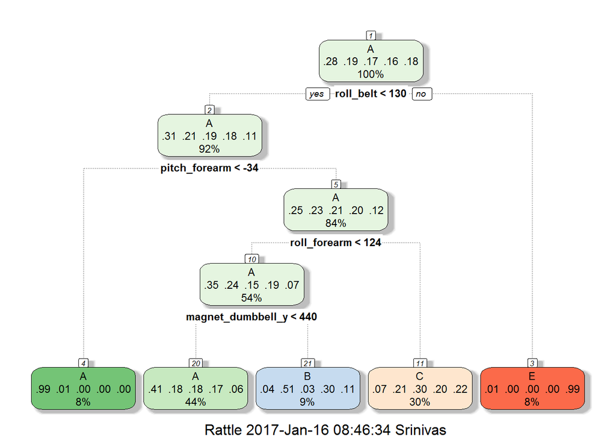

```r
set.seed(5678)
modRpart <- train(classe ~ ., method = "rpart", data = trainData, trControl = ctrl)
fancyRpartPlot(modRpart$finalModel)
```

```r
predRpart <- predict(modRpart,validData)
confRpart <- confusionMatrix(validData$classe,predRpart)
confRpart
```

```
## Confusion Matrix and Statistics
##
##           Reference
## Prediction    A    B    C    D    E
##          A 1525   24  120    0    5
##          B  486  290  363    0    0
##          C  502   15  509    0    0
##          D  421  146  397    0    0
##          E  163   62  333    0  524
##
## Overall Statistics
##
##                Accuracy : 0.4839
##                  95% CI : (0.4711, 0.4968)
##     No Information Rate : 0.5263
##     P-Value [Acc > NIR] : 1
##
##                   Kappa : 0.3255
##  Mcnemar's Test P-Value : NA
##
## Statistics by Class:
##
##                      Class: A Class: B Class: C Class: D Class: E
## Sensitivity            0.4924  0.54004  0.29559       NA  0.99055
## Specificity            0.9466  0.84125  0.87581   0.8362  0.89582
## Pos Pred Value         0.9110  0.25461  0.49610       NA  0.48429
## Neg Pred Value         0.6267  0.94796  0.75036       NA  0.99896
## Prevalence             0.5263  0.09125  0.29261   0.0000  0.08989
## Detection Rate         0.2591  0.04928  0.08649   0.0000  0.08904
## Detection Prevalence   0.2845  0.19354  0.17434   0.1638  0.18386
## Balanced Accuracy      0.7195  0.69064  0.58570       NA  0.94318
```

```r
confRpart$overall[1]
```

```
##  Accuracy
## 0.4839422
```

### Prediction with Random Forest Method

```r
set.seed(5678)
modRF <- train(classe~ ., data=trainData, method="rf", prox=TRUE, trControl = ctrl)
predRF <- predict(modRF,validData)
confRF <- confusionMatrix(validData$classe,predRF)
confRF
```

```
## Confusion Matrix and Statistics
##
##           Reference
## Prediction    A    B    C    D    E
##          A 1670    3    1    0    0
##          B    3 1133    3    0    0
##          C    0    5 1019    2    0
##          D    0    0   17  946    1
##          E    0    1    0    4 1077
##
## Overall Statistics
##
##                Accuracy : 0.9932
##                  95% CI : (0.9908, 0.9951)
##     No Information Rate : 0.2843
##     P-Value [Acc > NIR] : < 2.2e-16
##
##                   Kappa : 0.9914
##  Mcnemar's Test P-Value : NA
##
## Statistics by Class:
##
##                      Class: A Class: B Class: C Class: D Class: E
## Sensitivity            0.9982   0.9921   0.9798   0.9937   0.9991
## Specificity            0.9991   0.9987   0.9986   0.9964   0.9990
## Pos Pred Value         0.9976   0.9947   0.9932   0.9813   0.9954
## Neg Pred Value         0.9993   0.9981   0.9957   0.9988   0.9998
## Prevalence             0.2843   0.1941   0.1767   0.1618   0.1832
## Detection Rate         0.2838   0.1925   0.1732   0.1607   0.1830
## Detection Prevalence   0.2845   0.1935   0.1743   0.1638   0.1839
## Balanced Accuracy      0.9986   0.9954   0.9892   0.9950   0.9990
```

```r
confRF$overall[1]
```

```
##  Accuracy
## 0.9932031
```

### Prediction with Generalized Boosted method

```r
set.seed(5678)
modGBM <- train(classe ~ ., data = trainData, method="gbm", verbose=FALSE, trControl = ctrl)
predGBM <- predict(modGBM, validData)
confGBM <- confusionMatrix(validData$classe,predGBM)
confGBM
```

```
## Confusion Matrix and Statistics
##
##           Reference
## Prediction    A    B    C    D    E
##          A 1647   13   13    1    0
##          B   34 1068   33    1    3
##          C    0   17  995   14    0
##          D    0    1   35  925    3
##          E    0    9   10   10 1053
##
## Overall Statistics
##
##                Accuracy : 0.9665
##                  95% CI : (0.9616, 0.971)
##     No Information Rate : 0.2856
##     P-Value [Acc > NIR] : < 2.2e-16
##
##                   Kappa : 0.9577
##  Mcnemar's Test P-Value : NA
##
## Statistics by Class:
##
##                      Class: A Class: B Class: C Class: D Class: E
## Sensitivity            0.9798   0.9639   0.9162   0.9727   0.9943
## Specificity            0.9936   0.9851   0.9935   0.9921   0.9940
## Pos Pred Value         0.9839   0.9377   0.9698   0.9595   0.9732
## Neg Pred Value         0.9919   0.9916   0.9813   0.9947   0.9988
## Prevalence             0.2856   0.1883   0.1845   0.1616   0.1799
## Detection Rate         0.2799   0.1815   0.1691   0.1572   0.1789
## Detection Prevalence   0.2845   0.1935   0.1743   0.1638   0.1839
## Balanced Accuracy      0.9867   0.9745   0.9549   0.9824   0.9942
```

```r
confGBM$overall[1]
```

```
##  Accuracy
## 0.9665251
```

The accuracy in all the three methods are as follows

Accuracy of Trees method = 0.4839422

Accuracy of Random forest method = 0.9932031

Accuracy of gbm method = 0.9665251

The accuracy is better in Random Forest method with 0.9932031, so the out of sample error rate is 0.0067969. Therefore Random Forest method is chosen for the prediction.

## Final Prediction

```r
predFinal <- predict(modRF,test_clean)
predFinal
```

```
##  [1] B A B A A E D B A A B C B A E E A B B B
## Levels: A B C D E
```